# Data viz request

## Importing the data

I have saved the results of this procedure in an `RData` file which will be loaded with the following code (you should rename your filepath accordingly):

```r
#load("~/Dropbox/R working directory/raindata workspace.RData") #linux
load("~/R working directory/raindata workspace.RData") #windows
table.original <- tabla ## creates a working table saving the original one
```

## Fixing some issues and preparing data

We see that table column names are not appropriate, fixing that

```r
colnames(tabla) <- c("month",tabla[1,-1]) ## assignt the column names to the first row of data
tabla <- tabla[-1,] ## deletes the first row by subsetting all rows but the first one (symbolized by the minus sign)
```

Now I will use the `gather()` function in order to transform the “wide” format into the “long” format (one row per observation).

```r
my_table <- tabla %>%
  ## adding a column for the seasons
  mutate(season = c("Summer", "Summer", "Autumn", "Autumn", "Autumn", "Winter", "Winter", "Winter", "Spring", "Spring", "Spring", "Summer")) %>%
   ## sort each monthly observation in a single row
  gather("Year","Rainfall", c(-month,-season)) %>%
  subset(select = c(2,1,3,4))

head(my_table)
```

```
##   season    month Year Rainfall
## 1 Summer  January 1993       NA
## 2 Summer February 1993       NA
## 3 Autumn    March 1993       NA
## 4 Autumn    April 1993    266.1
## 5 Autumn      May 1993    125.3
## 6 Winter     June 1993     66.4
```

Now I will do some more tidying up in order to R understand better the variables we are using.

```r
my_table$Year <- as.integer(my_table$Year)
my_table$month <- factor(my_table$month, levels = month.name)
my_table$season <-as.factor(my_table$season)
my_table$season <- factor(my_table$season,  levels =c("Summer","Autumn","Winter","Spring"))
```

Now I’ll create a new categorical variable based on the intervals of the radar values. Since the values are in mm/hr, I’ll multiply each interval limit by 24.

```r
clipvalues <- c(0, 4.8,   12.0,   36.0,   60.0,   96.0,  144.0,  240.0,  360.0,  480.0,  840.0, 1200.0, 1920.0, 2880.0, 4800.0, 7200.0, 8640.0)
```

The `classIntervals` function from `classInt` package uses fixed breaks.

```r
require("classInt")
clippedvalues <- classIntervals(my_table$Rainfall, n = 14, style = "fixed", fixedBreaks = clipvalues)
clippedvalues
```

```
## style: fixed
##     [0,4.8)    [4.8,12)     [12,36)     [36,60)     [60,96)    [96,144)
##          11          14          45          40          46          28
##   [144,240)   [240,360)   [360,480)   [480,840)  [840,1200) [1200,1920)
##          33          35          15          29          10           3
## [1920,2880) [2880,4800) [4800,7200) [7200,8640]
##           0           0           0           0
```

```r
my_table$catRainfall <- cut(my_table$Rainfall, clipvalues)
```

## Creating relevant visualizations

The first graph is a line graph. It uses a graphing package inside R called `ggplot`, in which each layer of a graph is inserted sequentally by a series of commands.

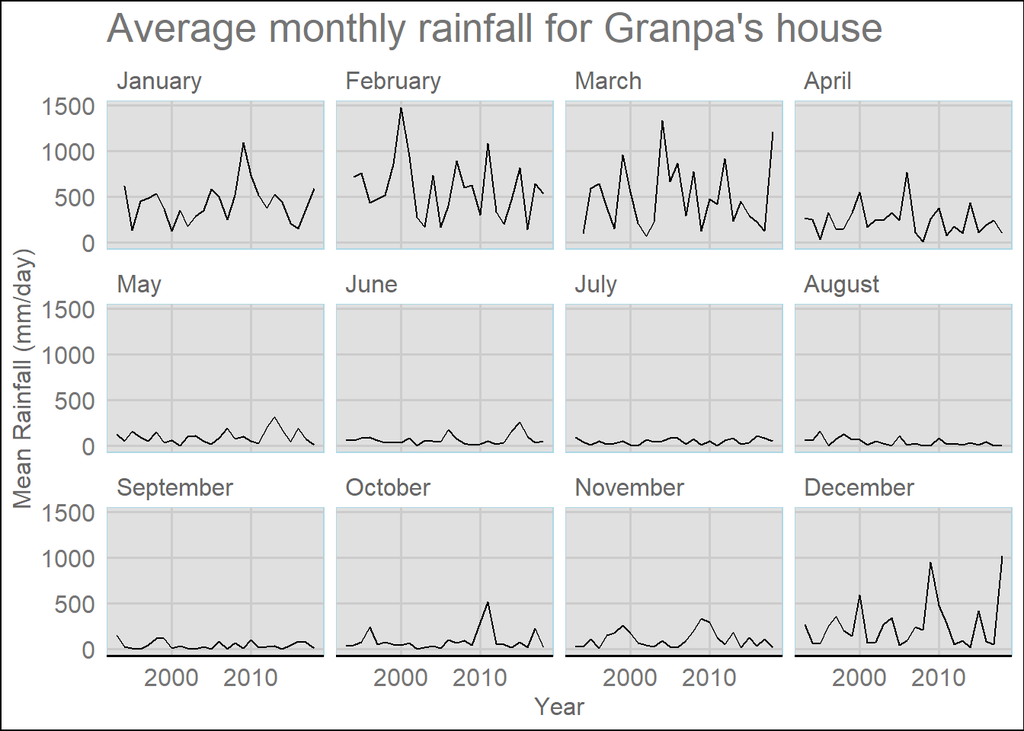

```r
# Specify which variable will go in each axis.
by.year <- ggplot(my_table, aes(x = Year, y=Rainfall))

#Having done that, we'll start adding layers to the base plot. Each layer is added with a plus sign
by.year +
  # stating this will be a line graph
  geom_line() +
  # facet creates a series of graphs, one for each month
  facet_wrap(~month) +
  # assign a theme for the plot
  theme_gdocs() +
  # specify the labels of each panel
  labs(title ="Average monthly rainfall for Granpa's house",
       x = "Year",
       y = "Mean Rainfall (mm/day)") +
  # further customizing the graph
  theme(
    panel.background = element_rect(fill = "grey88",
                                    colour = "lightblue",
                                    size = 0.5, linetype = "solid"))
```

Here is another graph, in this case a dot chart, following the same logic of the previous graph.

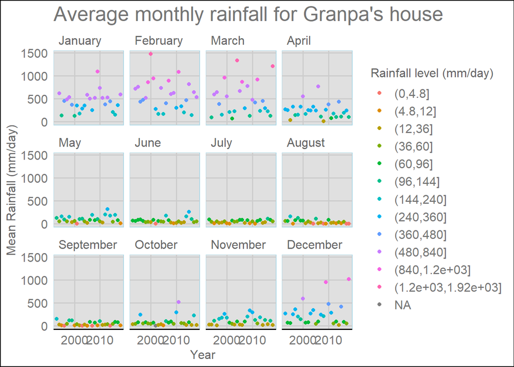

```r
by.year +
  geom_point(aes(color = catRainfall)) +
  facet_wrap(~month) +
  theme_gdocs() +
  labs(title ="Average monthly rainfall for Granpa's house",
       x = "Year",
       y = "Mean Rainfall (mm/day)") +
  scale_color_discrete(name = "Rainfall level (mm/day)") +
  theme(
  panel.background = element_rect(fill = "grey88",
                                colour = "lightblue",
                                size = 0.5, linetype = "solid"))
```

```r
year_rainfall_sum <- my_table %>%
  group_by(Year) %>%
  summarise(Rainfall = sum(Rainfall, na.rm = T))
year_rainfall_sum
```

```
## # A tibble: 26 x 2
##     Year Rainfall
##    <int>    <dbl>
##  1  1993    1088.
##  2  1994    2089
##  3  1995    2204.
##  4  1996    2629.
##  5  1997    2316.
##  6  1998    2271.
##  7  1999    3301.
##  8  2000    3716.
##  9  2001    2042.
## 10  2002    1154.
## # ... with 16 more rows
```

```r
mean(year_rainfall_sum$Rainfall)
```

```
## [1] 2458.696
```

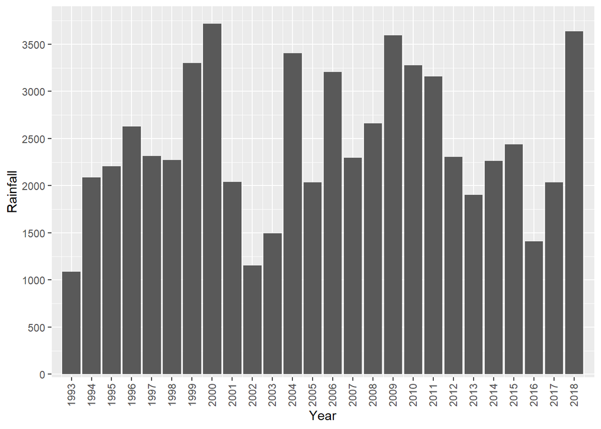

```r
bar_year_rainfall <- ggplot(data = year_rainfall_sum,
  aes(x = Year, y = Rainfall)) +
  # stat_summary(fun.y = sum, # adds up all observations for the month
  #   geom = "bar") +# or "line"
  geom_bar(stat = "identity") +
  scale_x_continuous(breaks=seq(1993,2018,1),
                     expand = expand_scale(mult = c(0, 0)),
                     limits = c(1992, 2019)) +
  scale_y_continuous(breaks = seq(0,4000,500),
                     expand = expand_scale(mult = c(0.009, .05))) +
  theme(axis.text.x = element_text(angle = 90,
                                   vjust = 0.4),
  legend.position="bottom")
bar_year_rainfall
```

```r
ggsave("bar_year_rainfall.png",
       plot = bar_year_rainfall,
       width = 10.5*2,
       height = 7.425*2,
       units = "cm",
       dpi=300)
```

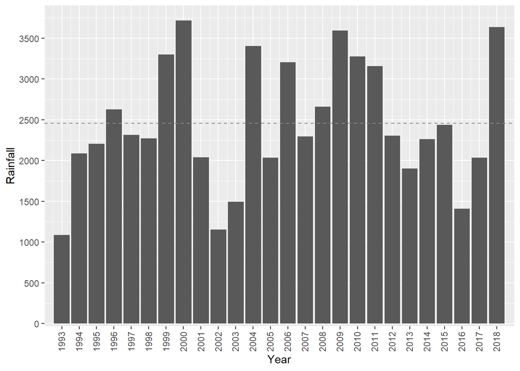

```r
bar_year_rainfall_w_avg_line <- bar_year_rainfall +
  geom_hline(yintercept = mean(year_rainfall_sum$Rainfall),
                               linetype="dashed",
                               color = "gray54",
                               size=0.5)
bar_year_rainfall_w_avg_line
```

```r
ggsave("bar_year_rainfall_w_avg_line.png",
       plot = bar_year_rainfall_w_avg_line,
       width = 10.5*2,
       height = 7.425*2,
       units = "cm",
       dpi=300)
```

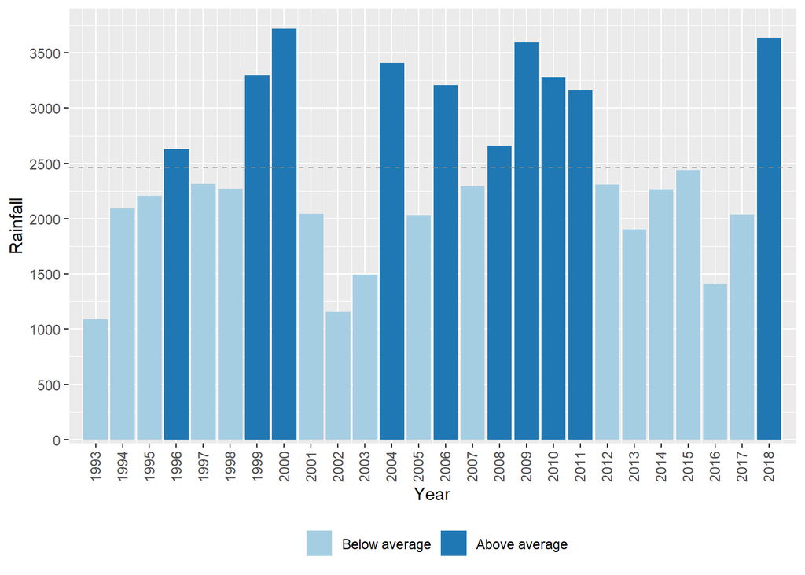

```r
bar_year_rainfall_w_avg_line_fill <- bar_year_rainfall_w_avg_line +
  aes(fill = Rainfall > mean(year_rainfall_sum$Rainfall))+
  scale_fill_brewer(palette = "Paired",
                    name = "",
                    labels = c("Below average", "Above average"))

bar_year_rainfall_w_avg_line_fill
```

```r
ggsave("bar_year_rainfall_w_avg_line_fill.png",
       plot = bar_year_rainfall_w_avg_line_fill,
       width = 10.5*2,
       height = 7.425*2,
       units = "cm",
       dpi=300)
```

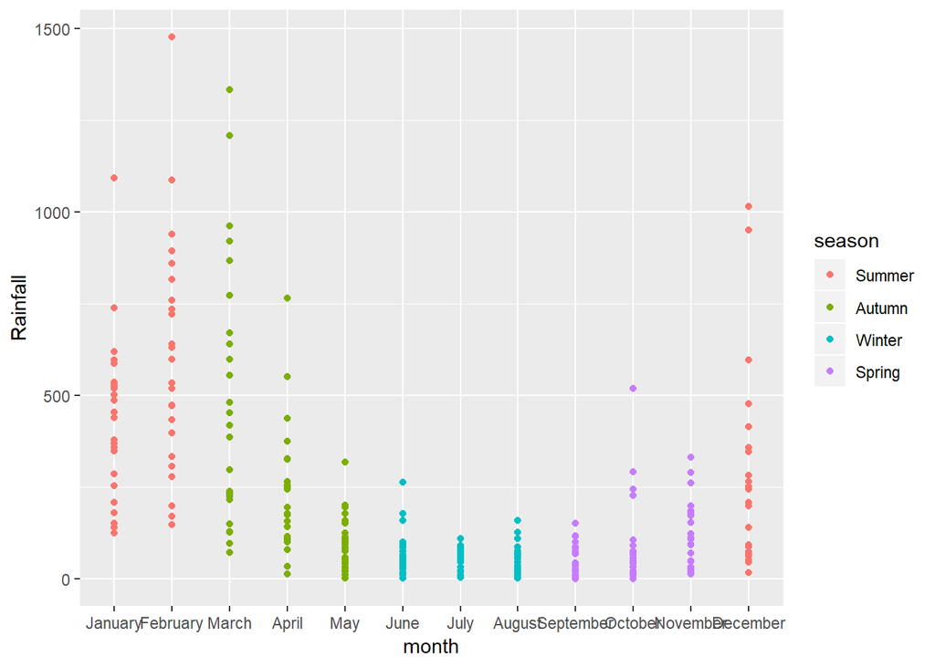

```r
by.month <- ggplot(my_table,
                   aes(x = month,
                       y=Rainfall,
                       color = season))

by.month + geom_point()
```

This graph changes the cartesian graph to a polar one, via the `coord_polar()` function.

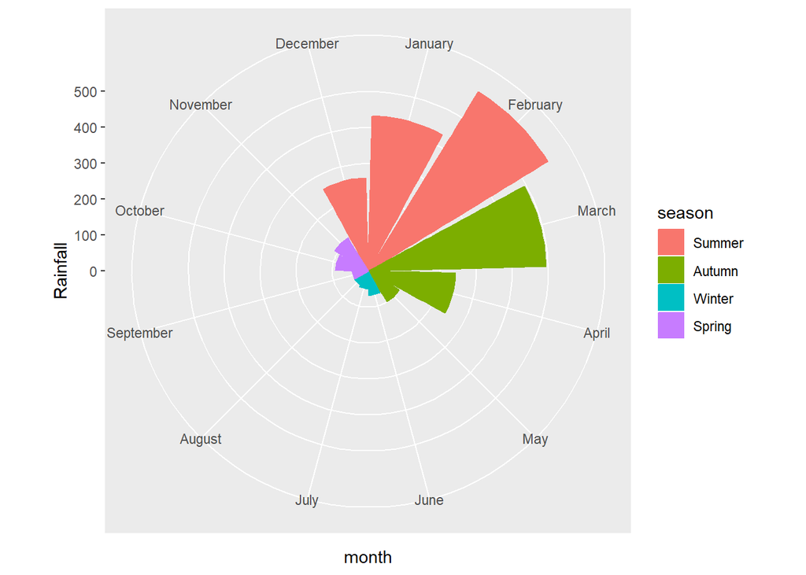

```r
## Average rainfall for each month, the whole period, colored by season
by.month +
  coord_polar() +
  stat_summary_bin(fun.y = "mean",
                   geom = "bar",
                   aes(fill = season))
```

Now the table has an extra column with a factor `catRainfall` that specifies to which binning the variable falls in.

First, I’ll create the palette that was extracted from that government website:

```r
my_palette <- c("#c9c9c9", "#B4B4FF", "#7878FF", "#1414FF", "#009690", "#006666", "#FFFF00", "#FFC800", "#FF9600", "#FF6400", "#FF0000", "#C80000", "#780000", "#280000")
```

And now the graph,

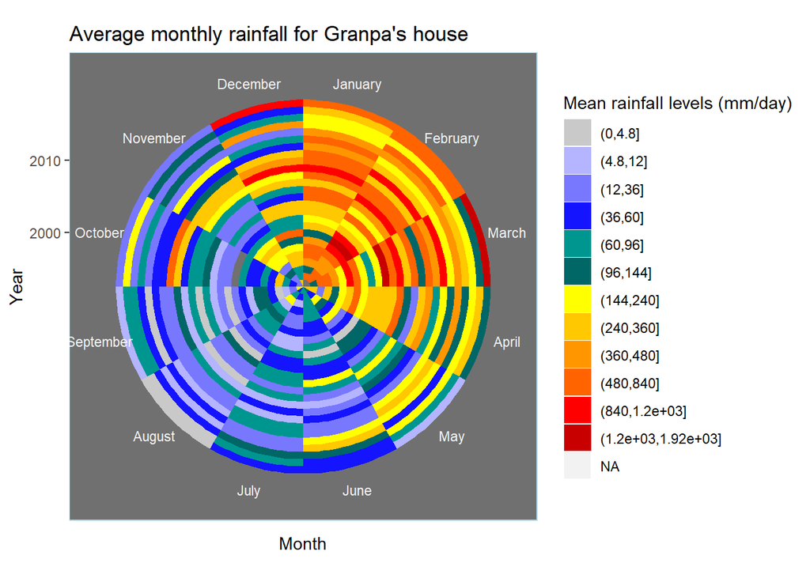

```r
#Setting the base variables
discrete_graph <- ggplot(my_table, aes(x = month, y = Year))


discrete_graph +
  coord_polar() +

  # this sets the type of graph in which each month represents a tile for the period.
  geom_tile(aes(fill = catRainfall )) +

  # this customize the values to the previously selected palette
  scale_fill_manual(values = my_palette, name = "Mean rainfall levels (mm/day)") +

  # customizing labels
  labs(title ="Average monthly rainfall for Granpa's house",
       x = "Month",
       y = "Year") +

  # further customizing
  theme(
  panel.background = element_rect(fill = "grey44",
                                colour = "lightblue",
                                size = 0.5, linetype = "solid"),
  panel.border = element_blank(),
          panel.grid.major = element_blank(),
          panel.grid.minor = element_blank(),
  axis.text.x=element_text(colour="grey96")
  )
```

The following chunk works for saving the last plotted graph. It won’t work properly during the knitting process, so I change the `eval` value to false.

```r
heyplot <- last_plot()

ggsave("radial_heatmap_discrete.png",
       plot = heyplot,
       width = 42/4,
       height = 29.7/4,
       units = "cm",
       dpi="print")
```

## Latest modifications

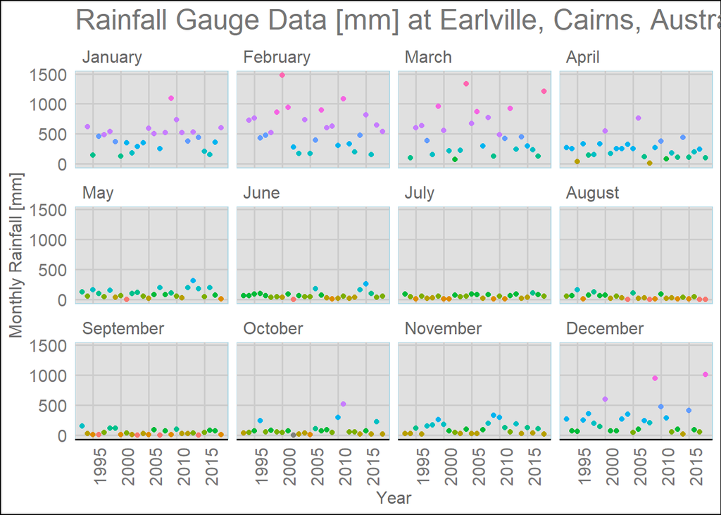

```r
monthly_by_year <- by.year +
  geom_point(aes(color = catRainfall),show.legend=FALSE) +
  facet_wrap(~month) +
  theme_gdocs() +
  labs(title ="Rainfall Gauge Data [mm] at Earlville, Cairns, Australia",
       x = "Year",
       y = "Monthly Rainfall [mm]") +
  theme(
  panel.background = element_rect(fill = "grey88",
                                colour = "lightblue",
                                size = 0.5, linetype = "solid"),
  axis.text.x = element_text(angle = 90,
                             hjust = 1)
  ) +
  scale_x_continuous(breaks=seq(1990,2020,5))


monthly_by_year
```

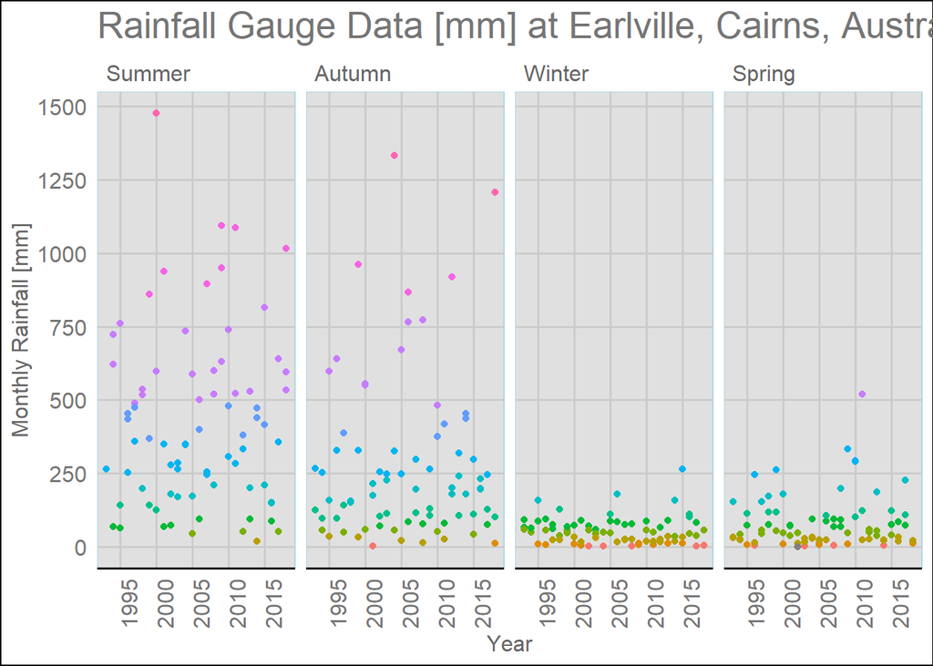

```r
## Uncomment the following to write an image file to the disk (Ctrl + Shift + C on a selection does the trick)

ggsave("dot_monthly_by_year.png",
       plot = monthly_by_year,
       width = 10.5*2,
       height = 7.425*2,
       units = "cm",
       dpi=300)
by.year <- ggplot(my_table, aes(x = Year, y=Rainfall))

dot_by_season <- by.year +
  geom_point(aes(color = catRainfall),show.legend=FALSE) +
  facet_wrap(~season,ncol = 4) +
  theme_gdocs() +
  labs(title ="Rainfall Gauge Data [mm] at Earlville, Cairns, Australia",
       x = "Year",
       y = "Monthly Rainfall [mm]")  +
  #scale_y_log10() +
  theme(
  panel.background = element_rect(fill = "grey88",
                                colour = "lightblue",
                                size = 0.5, linetype = "solid"),
  axis.text.x = element_text(angle = 90,
                             hjust = 1)
  ) +
  scale_x_continuous(breaks = seq(1990,2020,5)) +
  scale_y_continuous(breaks = seq(0,1500,250))

dot_by_season
```

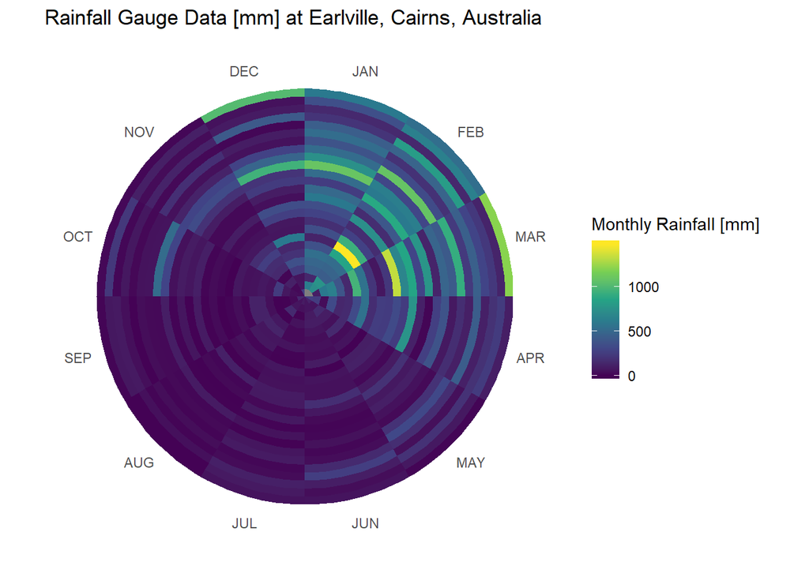

```r
dot_by_season_smooth <- dot_by_season + geom_smooth()

ggsave("dot_monthly_by_season_with_smooth.png",
       plot = dot_by_season_smooth,
       width = 10.5*2,
       height = 7.425*2,
       units = "cm",
       dpi=300)
ggsave("dot_monthly_by_season_no_smooth.png",
       plot = dot_by_season,
       width = 10.5*2,
       height = 7.425*2,
       units = "cm",
       dpi=300)
average_rainfall_radial <- ggplot(my_table,
                                  aes(x=month,
                                      y=Year)) +
  coord_polar() +
  geom_tile(aes(fill = Rainfall)) +
  labs(title ="Rainfall Gauge Data [mm] at Earlville, Cairns, Australia",
       x = "Month",
       y = "Year")


heat_viridis <- average_rainfall_radial +
  scale_fill_continuous(type = "viridis",
                        name = "Monthly Rainfall [mm]") +
  scale_x_discrete(labels = toupper(month.abb)) +
  theme(axis.title.y=element_blank(),
        axis.text.y=element_blank(),
        axis.ticks.y=element_blank(),
        axis.title.x=element_blank(),
        panel.background = element_rect(fill = "white")
        )


heat_viridis
```

```r
## Uncomment the following to write an image file to the disk (Ctrl + Shift + C on a selection does the trick)

ggsave("radial_heatmap_discrete_viridis.png",
       plot = heat_viridis,
       width = 10.5*2,
       height = 7.425*2,
       units = "cm",
       dpi=300)
```

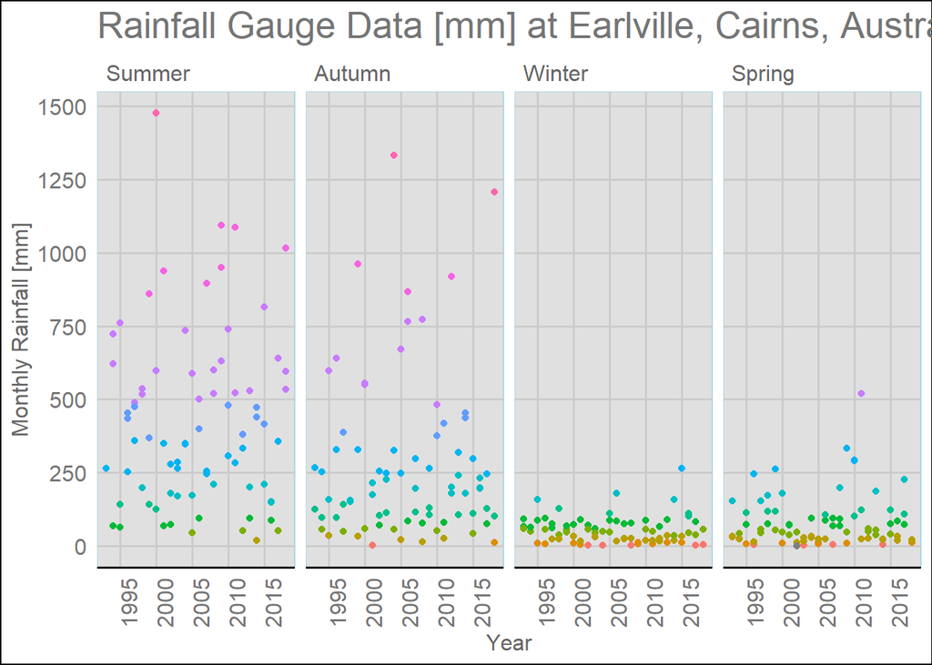

```r
by.year <- ggplot(my_table, aes(x = Year, y=Rainfall))

dot_by_season <- by.year +
  geom_point(aes(color = catRainfall),show.legend=FALSE) +
  facet_wrap(~season,ncol = 4) +
  theme_gdocs() +
  labs(title ="Rainfall Gauge Data [mm] at Earlville, Cairns, Australia",
       x = "Year",
       y = "Monthly Rainfall [mm]")  +
  #scale_y_log10() +
  theme(
  panel.background = element_rect(fill = "grey88",
                                colour = "lightblue",
                                size = 0.5, linetype = "solid"),
  axis.text.x = element_text(angle = 90,
                             hjust = 1)
  ) +
  scale_x_continuous(breaks = seq(1990,2020,5)) +
  scale_y_continuous(breaks = seq(0,1500,250))

dot_by_season
```

```r
dot_by_season_smooth <- dot_by_season + geom_smooth()

# ggsave("dot_monthly_by_season_with_smooth.png",
#        plot = dot_by_season_smooth,
#        width = 10.5*2,
#        height = 7.425*2,
#        units = "cm",
#        dpi=300)
#
# ggsave("dot_monthly_by_season_no_smooth.png",
#        plot = dot_by_season,
#        width = 10.5*2,
#        height = 7.425*2,
#        units = "cm",
#        dpi=300)
```